# Sustainability Behavior Analysis

Educational Research Study

2026-06-26

## 1 Introduction

This analysis evaluates the effectiveness of an educational intervention on sustainable behavior among students by comparing control and experimental groups across pre-test and post-test measurements. The study examines four key sustainability dimensions: proecological behavior (environmental conservation actions), frugality (resource-conscious consumption), equity (fairness and social justice awareness), and altruism (concern for others’ well-being). Using non-parametric statistical methods, we first verify that the control and experimental groups were equivalent at baseline through Mann-Whitney tests. Subsequently, we apply modified Wilcoxon signed-rank tests to assess whether significant behavioral changes occurred within each group after the intervention period. This comprehensive approach allows us to determine whether the educational intervention produced measurable improvements in sustainable behaviors in the experimental group while accounting for any natural changes that may have occurred in the control group over the same time period.

## 2 Survey data

Sample of Survey Data

| Timestamp | Username | Momento | Tipo.de.grupo | Profesor.del.grupo | proeco1 | proeco2 | proeco3 | proeco4 | proeco5 | proeco6 | proeco7 | proeco8 | proeco9 | proeco10 | proeco11 | proeco12 | proeco13 | proeco14 | proeco15 | proeco16 | frugal1 | frugal2 | frugal3 | frugal4 | frugal5 | frugal6 | frugal7 | frugal8 | frugal9 | … |
| --- | --- | --- | --- | --- | --- | --- | --- | --- | --- | --- | --- | --- | --- | --- | --- | --- | --- | --- | --- | --- | --- | --- | --- | --- | --- | --- | --- | --- | --- | --- |
| 45953.94 | 1 | Post | Experimental | Cinthya Flores | 3 | 3 | 1 | 2 | 2 | 3 | 1 | 2 | 2 | 3 | 3 | 2 | 2 | 3 | 1 | 3 | 4 | 4 | 4 | 4 | 4 | 4 | 4 | 2 | 0 | … |
| 45924.44 | 1 | Pre | Experimental | Cinthya Flores | 2 | 2 | 1 | 2 | 2 | 3 | 1 | 2 | 1 | 3 | 3 | 0 | 0 | 0 | 1 | 1 | 4 | 4 | 4 | 4 | 3 | 4 | 4 | 1 | 0 | … |
| 45951.96 | 2 | Post | Experimental | Cinthya Flores | 2 | 2 | 0 | 1 | 1 | 3 | 2 | 2 | 3 | 3 | 3 | 1 | 2 | 3 | 2 | 3 | 4 | 3 | 3 | 2 | 3 | 4 | 4 | 2 | 2 | … |
| 45924.44 | 2 | Pre | Experimental | Cinthya Flores | 0 | 0 | 1 | 1 | 2 | 3 | 1 | 1 | 1 | 1 | 2 | 0 | 1 | 0 | 2 | 3 | 3 | 2 | 0 | 3 | 2 | 0 | 0 | 0 | 0 | … |
| 45924.44 | 3 | Pre | Experimental | Cinthya Flores | 3 | 3 | 1 | 3 | 2 | 2 | 1 | 1 | 1 | 2 | 1 | 1 | 1 | 2 | 2 | 3 | 3 | 4 | 4 | 3 | 2 | 3 | 4 | 0 | 1 | … |
| 45923.44 | 4 | Pre | Experimental | Cinthya Flores | 3 | 3 | 2 | 2 | 1 | 3 | 2 | 2 | 1 | 2 | 0 | 1 | 0 | 2 | 2 | 3 | 4 | 4 | 4 | 4 | 2 | 4 | 3 | 3 | 1 | … |
| 45953.74 | 5 | Post | Experimental | Cinthya Flores | 3 | 3 | 1 | 3 | 0 | 2 | 1 | 2 | 1 | 2 | 2 | 1 | 1 | 1 | 1 | 1 | 4 | 0 | 0 | 3 | 4 | 2 | 4 | 3 | 2 | … |
| 45924.44 | 5 | Pre | Experimental | Cinthya Flores | 3 | 3 | 1 | 3 | 3 | 2 | 2 | 1 | 0 | 1 | 1 | 2 | 1 | 2 | 2 | 1 | 2 | 0 | 0 | 2 | 1 | 0 | 3 | 4 | 2 | … |
| 45924.43 | 6 | Pre | Experimental | Cinthya Flores | 2 | 2 | 1 | 3 | 2 | 3 | 1 | 2 | 1 | 3 | 1 | 2 | 1 | 2 | 3 | 3 | 4 | 4 | 4 | 3 | 4 | 1 | 2 | 1 | 2 | … |
| 45953.05 | 7 | Post | Experimental | Cinthya Flores | 3 | 3 | 1 | 2 | 1 | 3 | 1 | 2 | 1 | 2 | 1 | 2 | 1 | 2 | 3 | 3 | 3 | 4 | 4 | 4 | 3 | 1 | 3 | 2 | 2 | … |

## 3 Descriptive analysis

The following table shows the descriptive statistics for each factor by group (Control and Experimental) and stage (Pre and Post).

```
##
##  Descriptive statistics by group
## : Post
## : Control
##              vars  n mean   sd median trimmed  mad  min  max range  skew kurtosis   se
## proecologica    1 45 1.60 0.40   1.53    1.56 0.30 1.00 2.93  1.93  1.20     1.59 0.06
## frugalidad      2 45 2.42 0.52   2.50    2.41 0.59 1.30 4.00  2.70  0.38     0.58 0.08
## equidad         3 45 4.35 0.75   4.57    4.46 0.64 2.29 5.00  2.71 -1.30     0.72 0.11
## altruismo       4 45 2.75 0.60   2.70    2.72 0.44 1.70 4.00  2.30  0.39    -0.24 0.09
## ------------------------------------------------------------------------------------------------------------------------------------------------------
## : Pre
## : Control
##              vars  n mean   sd median trimmed  mad min max range  skew kurtosis   se
## proecologica    1 63 1.43 0.37   1.47    1.45 0.40 0.6 2.2   1.6 -0.26    -0.55 0.05
## frugalidad      2 63 2.33 0.48   2.40    2.35 0.44 1.3 3.4   2.1 -0.36    -0.46 0.06
## equidad         3 63 4.51 0.47   4.57    4.57 0.64 3.0 5.0   2.0 -1.07     0.95 0.06
## altruismo       4 63 2.61 0.59   2.60    2.57 0.59 1.7 4.0   2.3  0.48    -0.22 0.07
## ------------------------------------------------------------------------------------------------------------------------------------------------------
## : Post
## : Experimental
##              vars  n mean   sd median trimmed  mad  min  max range  skew kurtosis   se
## proecologica    1 59 1.74 0.35   1.67    1.72 0.40 0.93 2.73  1.80  0.42     0.01 0.05
## frugalidad      2 59 2.47 0.51   2.50    2.47 0.44 1.00 3.90  2.90 -0.12     0.62 0.07
## equidad         3 59 4.54 0.52   4.57    4.63 0.42 2.57 5.00  2.43 -1.74     3.56 0.07
## altruismo       4 59 2.86 0.59   2.90    2.84 0.59 1.70 4.00  2.30  0.32    -0.56 0.08
## ------------------------------------------------------------------------------------------------------------------------------------------------------
## : Pre
## : Experimental
##              vars  n mean   sd median trimmed  mad  min  max range  skew kurtosis   se
## proecologica    1 73 1.51 0.34   1.53    1.51 0.40 0.73 2.27  1.53  0.05    -0.65 0.04
## frugalidad      2 73 2.18 0.50   2.20    2.20 0.59 1.00 3.00  2.00 -0.19    -0.95 0.06
## equidad         3 73 4.50 0.48   4.57    4.56 0.42 3.00 5.00  2.00 -1.05     0.49 0.06
## altruismo       4 73 2.64 0.51   2.60    2.63 0.59 1.60 4.00  2.40  0.26    -0.43 0.06
```

## 4 Research Hypothesis

### 4.1 Pre-Control vs Pre-Experimental

We compare the pre-control and pre-experimental groups.

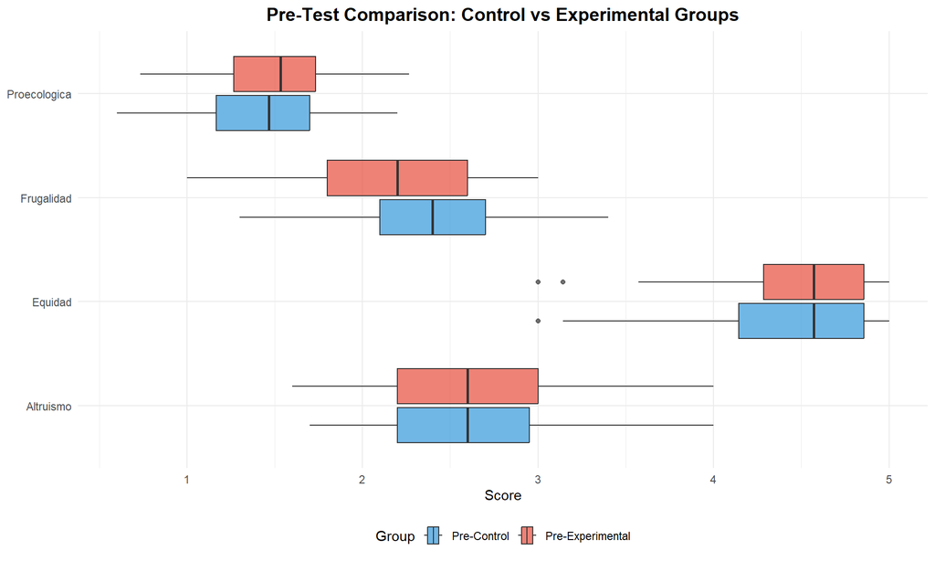

We use the Man Whitney test to prove that there is not difference between the control and experimental groups. The test statistics is
$$Z = \frac{U-E(U)}{\sqrt{Var(U)}}$$
where
$$U = \min\left\{ n_1n_2 + \frac{n_1(n_1+1)}{2} -R_1, n_1n_2 +
\frac{n_2(n_2+1)}{2} -R_2\right\},$$
$$E(U) = \frac{n_1(n_1+n_2+1)}{2},$$
$$\sigma_U = \sqrt{\frac{n_1n_2}{12}
\left(n_1+n_2+1-\frac{\sum_{k=1}^K(t_k^3-t_k)}{(n_1+n_2)(n_1+n_2+1)}\right)}.$$
$R_1$ and $R_2$ are the sum of the ranks in each group after pooling both samples, and $t_k$ is the number of ties values in the $i^{th}$ set of ties.

The following table shows the result for each factor.

Mann-Whitney Test Results: Pre-Control vs Pre-Experimental

|  | U1 | U2 | U | EU | s_U | Z | p.value |
| --- | --- | --- | --- | --- | --- | --- | --- |
| Proecologica | 4070.5 | 5245.5 | 4070.5 | 4315.5 | 229.1010 | -1.0694 | 0.2849 |
| Frugalidad | 4702.5 | 4613.5 | 4613.5 | 4315.5 | 229.1020 | 1.3007 | 0.1934 |
| Equidad | 4323.5 | 4992.5 | 4323.5 | 4315.5 | 228.9513 | 0.0349 | 0.9721 |
| Altruismo | 4195.0 | 5121.0 | 4195.0 | 4315.5 | 229.1022 | -0.5260 | 0.5989 |

### 4.2 Pre vs Post groups

We use the modified algorithm due to Cyprian, Oyeda and Ebuh (2012). We denote by $d_i$ the difference of the post-score of the i-th student from his pre-score in the particular indicator. As the usual Wilcoxon’s algorithm, the data is sorted according to $|d_i|$ and then its rank is assigned. The ties are resolved with the usual average. Then the sum of ranks is given by
$$T = \sum_{i=1}^n \hbox{rank}(|d_i|)Z_i,$$
where $Z_i$ is defined by $P(Z_i =1)=\pi^+$, $P(Z_i=0)=\pi^0$ and $P(Z_i=-1) = \pi^-$. Furthermore,
$$E(T) = \frac{n(n+1)}{2}(\pi^+ - \pi^-),$$
$$Var(T) = \frac{n(n+1)(2n+1)}{6}(\pi^+ + \pi^- (\pi^+ - \pi^-)^2)$$
and the test statistics is
$$Z = \frac{T}{\sqrt{Var(T)}}$$

We compare the pre and post for the control group with a box plot for each factor.

[figure not shown]

For the control group we got the following table.

Modified Wilcoxon Test Results: Control Group (Pre vs Post)

|  | Ties | Negatives | Positives | T.Neg | T.Pos | T | ET | Z | p.value |
| --- | --- | --- | --- | --- | --- | --- | --- | --- | --- |
| Proecologica | 4 | 11 | 25 | 209.5 | 600.5 | 391 | 287.0 | 2.9801 | 0.0029 |
| Frugalidad | 1 | 16 | 23 | 380.0 | 439.0 | 59 | 143.5 | 0.4080 | 0.6833 |
| Equidad | 11 | 16 | 13 | 438.5 | 315.5 | -123 | -61.5 | -0.9746 | 0.3297 |
| Altruismo | 9 | 9 | 22 | 206.5 | 568.5 | 362 | 266.5 | 2.9736 | 0.0029 |

Now we applied the modified Wilcoxon test to the experimental group data.

[figure not shown]

Modified Wilcoxon Test Results: Experimental Group (Pre vs Post)

|  | Ties | Negatives | Positives | T.Neg | T.Pos | T | ET | Z | p.value |
| --- | --- | --- | --- | --- | --- | --- | --- | --- | --- |
| Proecologica | 3 | 12 | 44 | 213.0 | 1551.0 | 1338 | 960 | 6.2394 | 0.0000 |
| Frugalidad | 6 | 13 | 40 | 340.5 | 1408.5 | 1068 | 810 | 4.8562 | 0.0000 |
| Equidad | 20 | 16 | 23 | 675.0 | 885.0 | 210 | 210 | 0.9853 | 0.3245 |
| Altruismo | 3 | 18 | 38 | 492.5 | 1271.5 | 779 | 600 | 3.2188 | 0.0013 |

## 5 Summary of Results

### 5.1 Key Findings

Statistical Analysis Overview

| Test | Purpose | Method |
| --- | --- | --- |
| Pre-Control vs Pre-Experimental | Verify groups are equivalent at baseline | Mann-Whitney Test |
| Control Group (Pre vs Post) | Check for changes without intervention | Modified Wilcoxon Test |
| Experimental Group (Pre vs Post) | Assess intervention effectiveness | Modified Wilcoxon Test |

### 5.2 Interpretation Guide

- **p-value < 0.05**: Statistically significant difference
- **p-value ≥ 0.05**: No significant difference

## 6 References

Minitab LLC. (2025). Métodos y fórmulas para la Prueba de Mann-Whitney. Minitab Help & How-to (Spanish). Retrieved from https://support.minitab.com/es-mx/minitab/help-and-how-to/statistics/nonparametrics/how-to/mann-whitney-test/methods-and-formulas/methods-and-formulas/

Oyeka, I. C. A., & Ebuh, G. U. (2012). Modified Wilcoxon signed-rank test. Open Journal of Statistics, 2(2), 172-176.